# Мастер-класс по анализу данных решений арбитражных судов в R

# Арбитражные дела государства против предпринимателей

```r
summary(subset(commercial_courts_cases,pair=="Гос. орган vs. Предприниматель")$sum_dec)
```

```
##      Min.   1st Qu.    Median      Mean   3rd Qu.      Max.      NA's
##         2       194      3188    695700     72500 578200000       593
```

Самые частовстречающиеся суммы исков:

```r
head(sort(table(subset(commercial_courts_cases,pair=="Гос. орган vs. Предприниматель")$sum_dec),
          decreasing = TRUE))
```

```
##
## 184.8 386.4 123.2 257.6  3000   180
##   218   162   131    95    53    38
```

# dplyr и таблички (пары)

Зашли визуально, теперь подойдем к суммам исков с помощью таблиц медиан. Используем пакет dplyr:

```r
commercial_courts_cases %>%
  filter(!is.na(sum_dec)) %>%
  group_by(pair) %>%
  summarise("Медиана суммы иска"=median(sum_dec),Частота = n()) %>%
  mutate (Доля = Частота / sum(Частота)) %>%
  arrange(desc(Доля))
```

```
## # A tibble: 5 × 4
##                                 pair `Медиана суммы иска` Частота
##                                <chr>                <dbl>   <int>
## 1 Предприниматель vs Предприниматель            105826.94    4708
## 2     Гос. орган vs. Предприниматель              3188.44    2723
## 3      Предприниматель vs Гос. орган            100000.00     637
## 4           Гос. орган vs Гос. орган              9164.45     180
## 5                               <NA>            665840.00      35
##          Доля
##         <dbl>
## 1 0.568393094
## 2 0.328745624
## 3 0.076904503
## 4 0.021731257
## 5 0.004225522
```

# dplyr и таблички (заявители)

То же самое, но для каждого из заявителей:

```r
commercial_courts_cases %>%
  filter(!is.na(sum_dec)) %>%
  group_by(dec_type) %>%
  summarise("Медиана суммы иска"=median(sum_dec),Частота = n()) %>%
  mutate (Доля = Частота / sum(Частота)) %>%
  arrange(desc(Доля))
```

```
## # A tibble: 39 × 4
##           dec_type `Медиана суммы иска` Частота       Доля
##              <chr>                <dbl>   <int>      <dbl>
## 1              ООО             168000.0    2463 0.29735603
## 2  Пенсионный фонд                386.4    1636 0.19751298
## 3              ОАО              51343.0    1459 0.17614391
## 4              ЗАО             129133.4     534 0.06446940
## 5 Налоговые органы               7994.0     525 0.06338283
## 6               ИП              76500.0     347 0.04189303
## # ... with 33 more rows
```

# Группировка сумм по группам

```r
commercial_courts_cases$sum_grouped <- cut(commercial_courts_cases$sum_dec,
      breaks = c(-Inf, 1000, 10000, 50000, 100000, 500000, Inf),
      labels = c("<1 т.р.", "1-10 т.р.", "10-50 т.р.", "50-100 т.р.", "100-500 т.р.", ">500т.р."),
      right = FALSE)

table(commercial_courts_cases$pair, commercial_courts_cases$sum_grouped)
```

```
##
##                                      <1 т.р. 1-10 т.р. 10-50 т.р.
##   Гос. орган vs Гос. орган                49        44         39
##   Гос. орган vs. Предприниматель        1147       440        336
##   Предприниматель vs Гос. орган           10        78        169
##   Предприниматель vs Предприниматель      25       518       1159
##
##                                      50-100 т.р. 100-500 т.р. >500т.р.
##   Гос. орган vs Гос. орган                    12           22       14
##   Гос. орган vs. Предприниматель             215          383      202
##   Предприниматель vs Гос. орган               60          137      183
##   Предприниматель vs Предприниматель         585         1208     1213
```

# Медианы в каждой подгруппе суммы иска

```r
commercial_courts_cases %>%
  filter(!is.na(sum_dec)) %>%
  group_by(sum_grouped) %>%
  summarise("Медиана суммы иска"=median(sum_dec),Частота = n()) %>%
  mutate (Доля = Частота / sum(Частота))
```

```
## # A tibble: 6 × 4
##    sum_grouped `Медиана суммы иска` Частота      Доля
##         <fctr>                <dbl>   <int>     <dbl>
## 1      <1 т.р.               184.80    1232 0.1487384
## 2    1-10 т.р.              4116.29    1083 0.1307497
## 3   10-50 т.р.             23413.38    1706 0.2059640
## 4  50-100 т.р.             69946.68     874 0.1055173
## 5 100-500 т.р.            200000.00    1753 0.2116383
## 6     >500т.р.           1554168.00    1635 0.1973922
```

# Длительность рассмотрения дел

Переменные длительности рассмотрения дел: - **date_bil** - дата подачи заявления - **date_ses** - дата первого судебного заседания - **date_des** - дата первого судебного решения

Вычисляем разницу:

```r
commercial_courts_cases$time_diff_bill_to_court <- as.numeric(
  as.Date(as.character(date_ses), format="%Y-%m-%d")-
  as.Date(as.character(date_bil), format="%Y-%m-%d"))

commercial_courts_cases$time_diff_bill_to_decision <- as.numeric(
  as.Date(as.character(date_des), format="%Y-%m-%d")-
  as.Date(as.character(date_bil), format="%Y-%m-%d"))

commercial_courts_cases$time_diff_court_to_decision <- as.numeric(
  as.Date(as.character(date_des), format="%Y-%m-%d")-
  as.Date(as.character(date_ses), format="%Y-%m-%d"))
```

# Связь между продолжительностью рассмотрения иска и судебным разбирательством

Можно вычислить коэффициент корреляции:

```r
cor(commercial_courts_cases$time_diff_bill_to_court,
    commercial_courts_cases$time_diff_court_to_decision,
    method = "spearman", use = "pairwise.complete.obs")
```

```
## [1] 0.06714762
```

… но лучше визуализировать:

```r
ggplot(commercial_courts_cases,aes(x=time_diff_bill_to_court, y = time_diff_court_to_decision)) +
  geom_point(alpha=0.1)+
  xlab("От подачи заявления до первого суда, в днях")+
  ylab("От первого суда до решения суда, в днях")+
  ggtitle("Время рассмотрения VS время разбирательства")+
  theme_bw() +
  theme(axis.line = element_line(colour = "black"),
        plot.title = element_text(hjust = 0.5))
```

# Связь между продолжительностью рассмотрения иска и судебным разбирательством

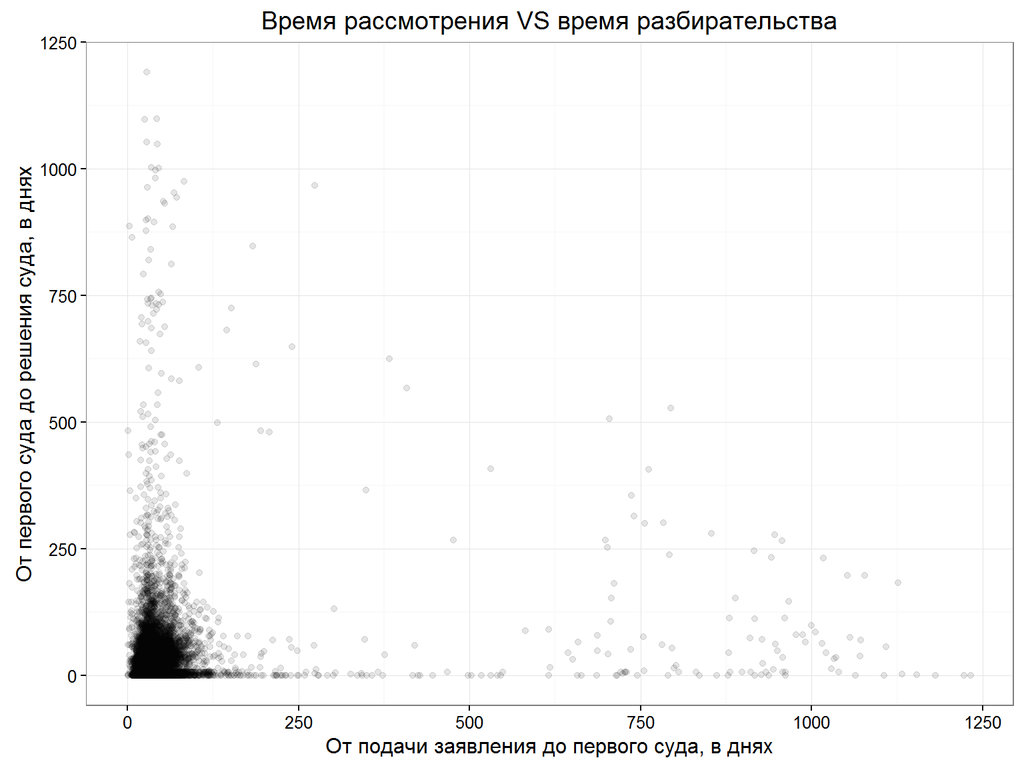

# Отсечка по 200 дням

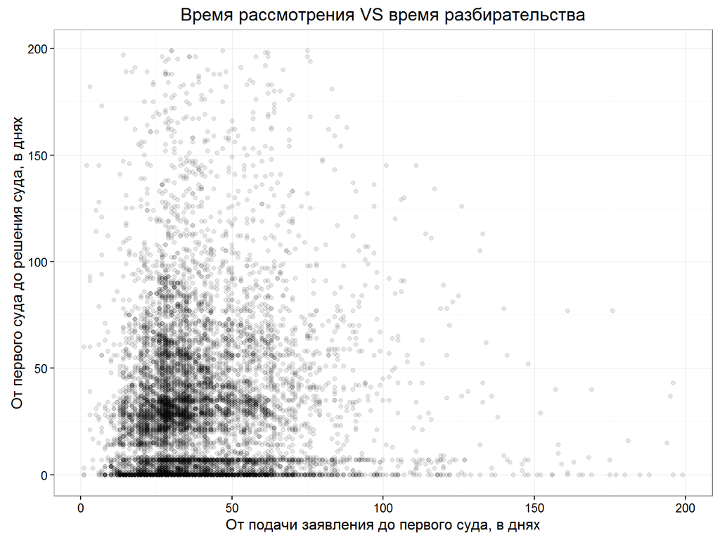

# Регионы: где рассматривают арбитражные дела дольше всего?

```r
commercial_courts_cases %>%
  group_by(regi) %>%
  summarise("Иск->Суд"=median(time_diff_bill_to_court, na.rm = TRUE),
            "Суд->Решение"=median(time_diff_court_to_decision, na.rm = TRUE),
            "Иск->Решение"=median(time_diff_bill_to_decision, na.rm = TRUE),
            Частота = n()) %>%
  mutate (Доля = Частота / sum(Частота)) %>%
  arrange(desc(Доля))
```

```
## # A tibble: 80 × 6
##                                      regi `Иск->Суд` `Суд->Решение`
##                                     <chr>      <dbl>          <dbl>
## 1                                  Москва         56           35.5
## 2 Санкт-Петербург и Ленинградская область         50            7.0
## 3                    Свердловская область         43           25.0
## 4                      Московская область         40           49.0
## 5                      Краснодарский край         39           28.0
## 6                   Нижегородская область         42            7.0
##   `Иск->Решение` Частота       Доля
##            <dbl>   <int>      <dbl>
## 1            108    1082 0.09932984
## 2             65     651 0.05976315
## 3             65     422 0.03874048
## 4             89     354 0.03249793
## 5             77     332 0.03047829
## 6             56     302 0.02772423
## # ... with 74 more rows
```

# Где рассматривают быстрее всего?

```r
commercial_courts_cases %>%
  group_by(regi) %>%
  summarise("Иск->Суд"=median(time_diff_bill_to_court, na.rm = TRUE),
            "Суд->Решение"=median(time_diff_court_to_decision, na.rm = TRUE),
            "Иск_Решение"=median(time_diff_bill_to_decision, na.rm = TRUE),
            Частота = n()) %>%
  mutate (Доля = Частота / sum(Частота)) %>%
  arrange(Иск_Решение)
```

```
## # A tibble: 80 × 6
##                 regi `Иск->Суд` `Суд->Решение` Иск_Решение Частота
##                <chr>      <dbl>          <dbl>       <dbl>   <int>
## 1          Ингушетия       21.0              2          29      11
## 2       Еврейская АО       23.5             18          42      17
## 3 Смоленская область       32.0              7          42      66
## 4             Адыгея       27.0             15          43      31
## 5           Калмыкия       21.0             28          43      24
## 6  Псковская область       33.0             14          44      48
##          Доля
##         <dbl>
## 1 0.001009823
## 2 0.001560635
## 3 0.006058937
## 4 0.002845864
## 5 0.002203250
## 6 0.004406500
## # ... with 74 more rows
```

# Длительность рассмотрения и пары заявитель-истец

```r
commercial_courts_cases %>%
  group_by(pair) %>%
  summarise("Иск->Суд"=median(time_diff_bill_to_court, na.rm = TRUE),
            "Суд->Решение"=median(time_diff_court_to_decision, na.rm = TRUE),
            "Иск_Решение"=median(time_diff_bill_to_decision, na.rm = TRUE),
            Частота = n()) %>%
  mutate (Доля = Частота / sum(Частота)) %>%
  arrange(desc(Иск_Решение))
```

```
## # A tibble: 5 × 6
##                                 pair `Иск->Суд` `Суд->Решение` Иск_Решение
##                                <chr>      <dbl>          <dbl>       <dbl>
## 1                               <NA>         54           38.5         599
## 2 Предприниматель vs Предприниматель         40           32.0          75
## 3      Предприниматель vs Гос. орган         30           30.0          62
## 4           Гос. орган vs Гос. орган         30           23.5          54
## 5     Гос. орган vs. Предприниматель         31            7.0          47
##   Частота        Доля
##     <int>       <dbl>
## 1     105 0.009639218
## 2    5340 0.490223079
## 3    1772 0.162673276
## 4     360 0.033048747
## 5    3316 0.304415680
```

# Длительность и типы заявителей

```r
commercial_courts_cases %>%
  group_by(dec_type) %>%
  summarise("Иск->Суд"=median(time_diff_bill_to_court, na.rm = TRUE),
            "Суд->Решение"=median(time_diff_court_to_decision, na.rm = TRUE),
            "ИскРешение"=median(time_diff_bill_to_decision, na.rm = TRUE),
            Частота = n()) %>%
  mutate (Доля = Частота / sum(Частота)) %>%
  arrange(desc(ИскРешение))
```

```
## # A tibble: 40 × 6
##                      dec_type `Иск->Суд` `Суд->Решение` ИскРешение Частота
##                         <chr>      <dbl>          <dbl>      <dbl>   <int>
## 1                        <NA>     1040.0            7.0      845.0       8
## 2                    физ лица       46.0           65.0      136.0      74
## 3                       ФСФБН       31.5           84.5      116.0       4
## 4                минфин казна       28.0           76.0      104.0       3
## 5 Прочие виды юридических лиц       50.0           50.0       96.5      29
## 6       военные подразделения       39.0           48.0       87.5      14
##           Доля
##          <dbl>
## 1 0.0007344166
## 2 0.0067933535
## 3 0.0003672083
## 4 0.0002754062
## 5 0.0026622602
## 6 0.0012852290
## # ... with 34 more rows
```

# Длительность и типы заявителей

```r
commercial_courts_cases %>%
  group_by(dec_type) %>%
  summarise("Иск->Суд"=median(time_diff_bill_to_court, na.rm = TRUE),
            "Суд->Решение"=median(time_diff_court_to_decision, na.rm = TRUE),
            "ИскРешение"=median(time_diff_bill_to_decision, na.rm = TRUE),
            Частота = n()) %>%
  mutate (Доля = Частота / sum(Частота)) %>%
  arrange(ИскРешение)
```

```
## # A tibble: 40 × 6
##         dec_type `Иск->Суд` `Суд->Решение` ИскРешение Частота         Доля
##            <chr>      <dbl>          <dbl>      <dbl>   <int>        <dbl>
## 1           ГАДН         20            0.5       21.0     109 0.0100064261
## 2  Санэпиднадзор         33            0.0       33.0       2 0.0001836041
## 3           ФССП         28           11.0       34.5      16 0.0014688332
## 4   Ростехнадзор         28            7.0       38.0      29 0.0026622602
## 5    Прокуратура         25            6.0       38.5     207 0.0190030295
## 6 Росстройнадзор         21            1.0       40.0       9 0.0008262187
## # ... with 34 more rows
```

# Связаны ли сумма иска и длительность дела?

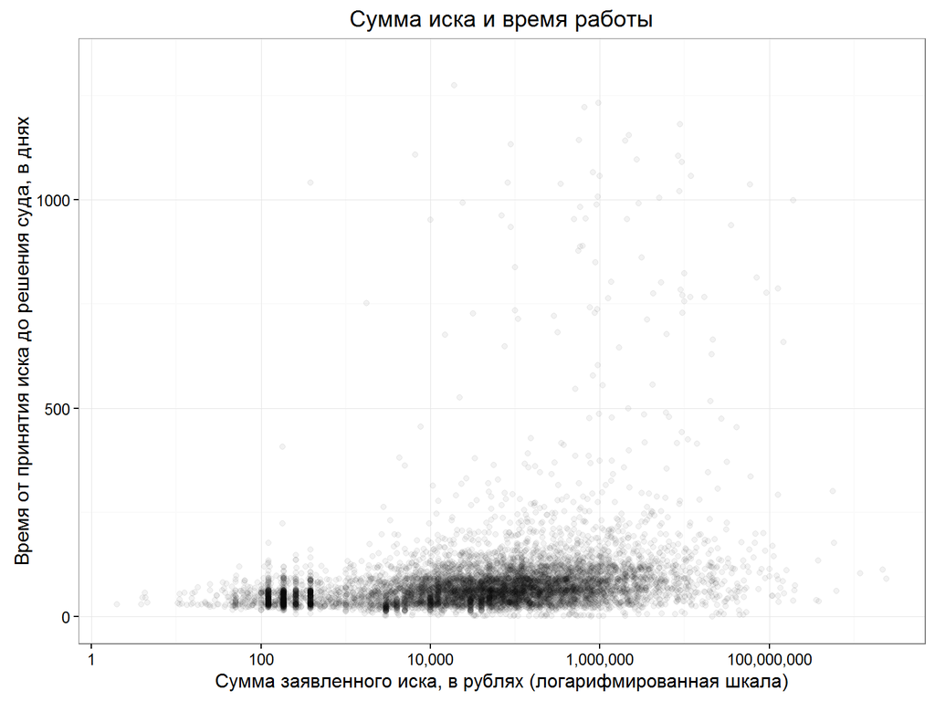

```r
ggplot(commercial_courts_cases,aes(x=sum_dec, y = time_diff_bill_to_decision)) +
  geom_point(alpha=0.05)+
  scale_x_continuous(trans = 'log10',
                     breaks = trans_breaks('log10', function(x) 10^x),
                     labels = comma)+
  xlab("Сумма заявленного иска, в рублях (логарифмированная шкала)")+
  ylab("Время от принятия иска до решения суда, в днях")+
  ggtitle("Сумма иска и время работы")+
  theme_bw() +
  theme(axis.line = element_line(colour = "black"),
        plot.title = element_text(hjust = 0.5))
```

# Конец

Всё про эту презетацию есть здесь:  
https://github.com/alexeyknorre/Rbitrazh

Контакты:  
alexeyknorre.ru  
vk.com/alexeyknorre  
aknorre@eu.spb.ru